## **Part 1 - Import NVIDIA stock data using quantmod and visualize the closing prices over time.**

### **Load necessary packages**

```r
library(quantmod)
```

### **Importing NVIDIA stock data using quantmod**

```r
getSymbols("NVDA", src = "yahoo", from = "2023-04-01", to = "2024-04-01")
```

```
## [1] "NVDA"
```

### **Visualization of NVIDIA’s Gains & Losses over a period of 1 year**

#### **Green = gains; Red = losses**

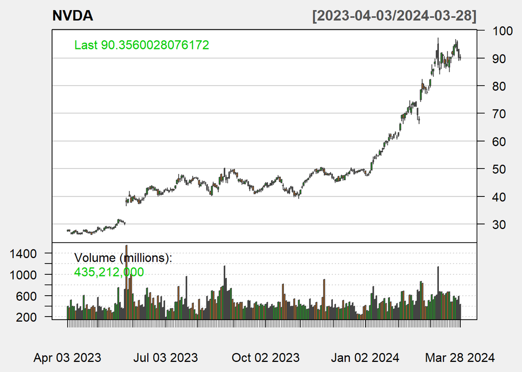

```r
chartSeries(NVDA, theme = chartTheme("white"))
```

## **Part 2 - Calculate daily and monthly returns for NVIDIA and Create plots showing price trends and returns.**

### **Calculate daily returns using the quantmod package with the function dailyReturn().**

#### **This function computes the percentage change between the closing prices of two consecutive days (y axis = rate of change).**

```r
NVDA_daily_returns <- dailyReturn(NVDA)
```

### **Calculate monthly returns using the quantmad package.**

#### **Involves converting daily stock prices to monthly prices and then computing the returns based on these monthly prices.**

```r
NVDA_monthly_returns <- monthlyReturn(NVDA)
```

### **Visualizing daily returns of NVDA**

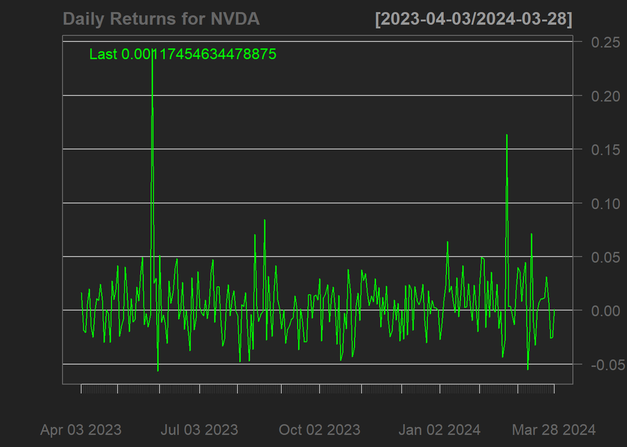

```r
barChart(NVDA_daily_returns, theme = chartTheme("black", grid.col="gray"), name =  "Daily Returns for NVDA")
```

### **Visualizing monthly returns of NVDA**

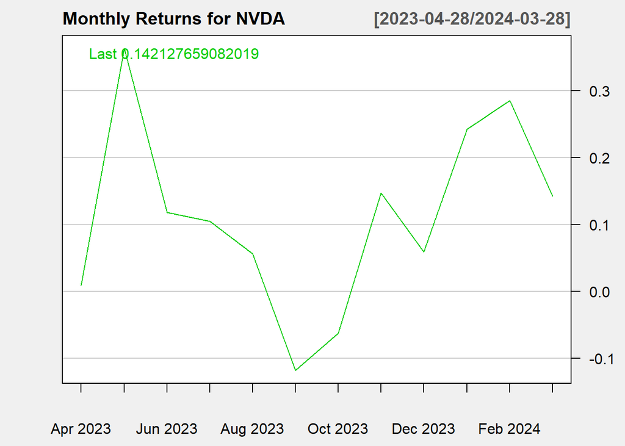

```r
barChart(NVDA_monthly_returns, theme = chartTheme("white"), name = "Monthly Returns for NVDA")
```

## **Part 3 - Compute and plot moving averages and volatility for NVIDIA and Apply technical indicators to generate trading signals.**

### **Moving averages**

#### **SMA calculates the arithmetic mean of the series over the past n observations.**

#### **Enhanced chart with volume and SMA overlays**

#### **Visualization with SMA = 20**

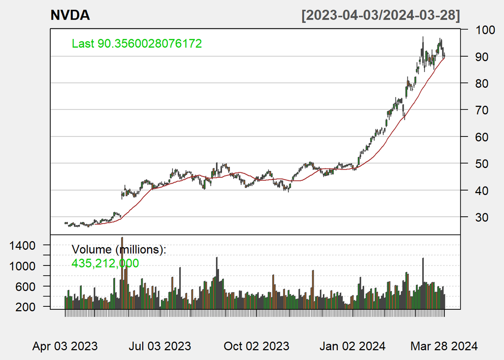

```r
chartSeries(NVDA, TA = "addVo();addSMA(20)",theme = chartTheme("white"))
```

#### **Visualization with SMA = 50**

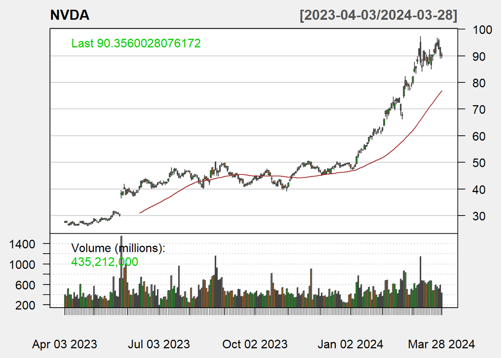

```r
chartSeries(NVDA, TA = "addVo();addSMA(50)",theme = chartTheme("white"))
```

### **Volatility (standard deviation of daily returns)**

#### **Volatility is a statistical measure of the dispersion of returns for a given security or market index, and it’s typically used to quantify the risk associated with a particular investment.**

```r
NVDA_volatility <- runSD(NVDA_daily_returns, n = 20)
```

#### **Plotting volatility**

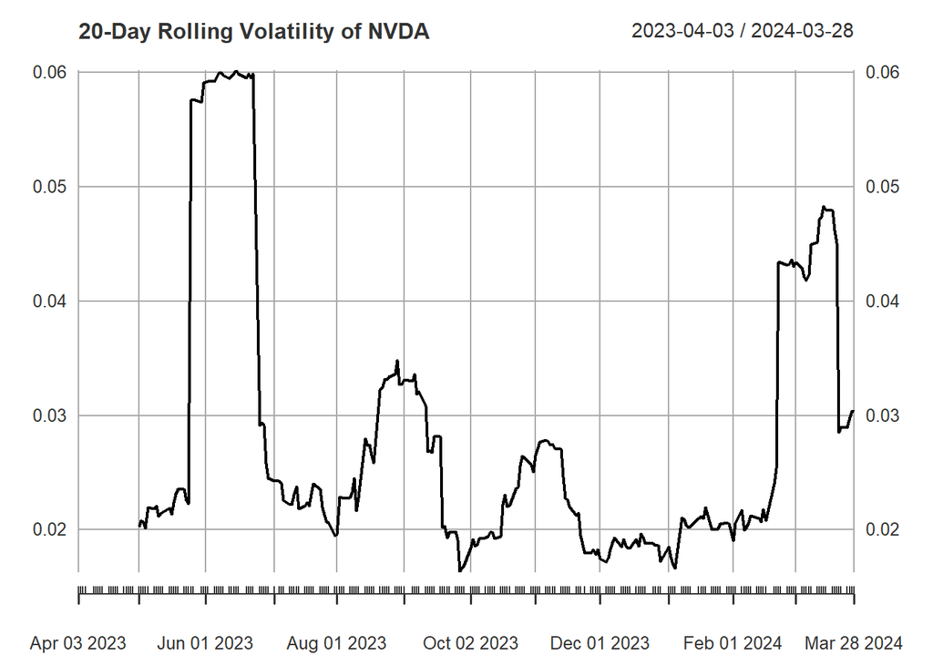

```r
plot(NVDA_volatility, main = "20-Day Rolling Volatility of NVDA")
```

### **Technical indicators**

#### **Moving Average Convergence/Divergence (MACD)**

##### **Relative Strength Index (RSI) calculates a ratio of the recent upward price movements to the absolute price movement.**

```r
NVDA_macd_vals <- MACD(Cl(NVDA))
NVDA_rsi_vals <- RSI(Cl(NVDA))
```

#### **Plotting MACD of NVDA**

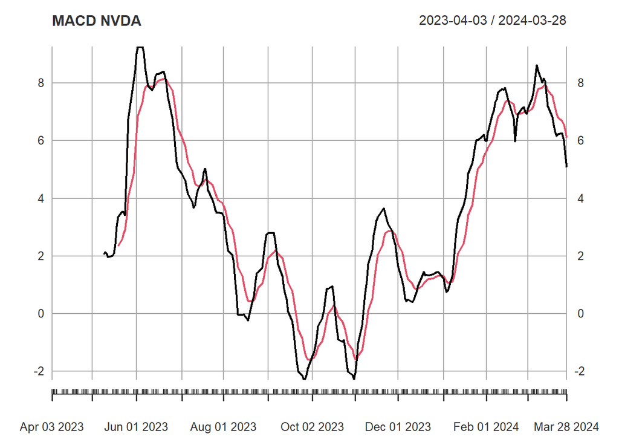

```r
plot(NVDA_macd_vals, main = "MACD NVDA")
```

#### **Plotting RSI of NVDA**

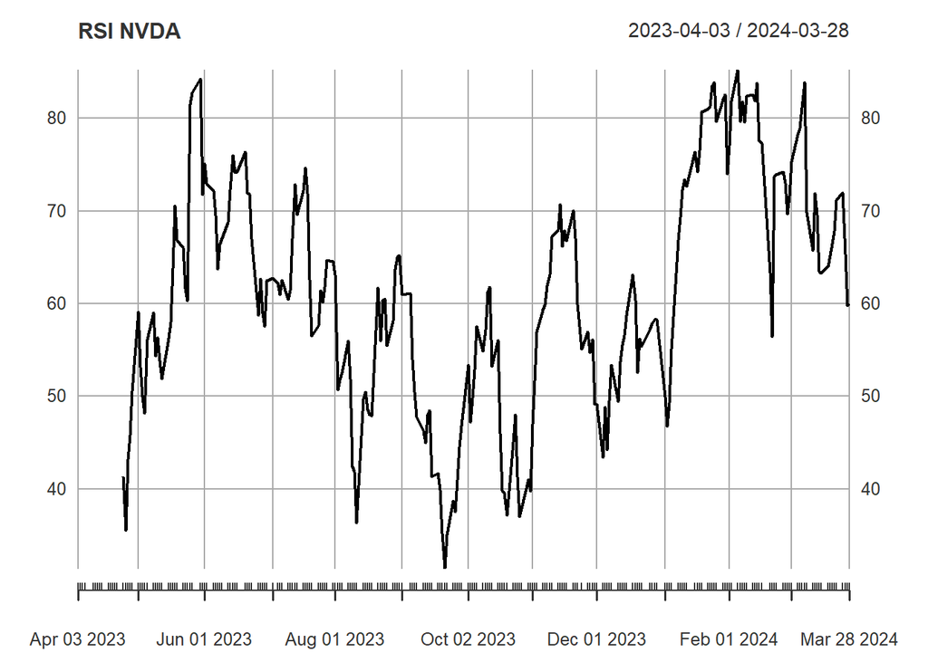

```r
plot(NVDA_rsi_vals, main = "RSI NVDA")
```

#### **Plotting with technical indicators**

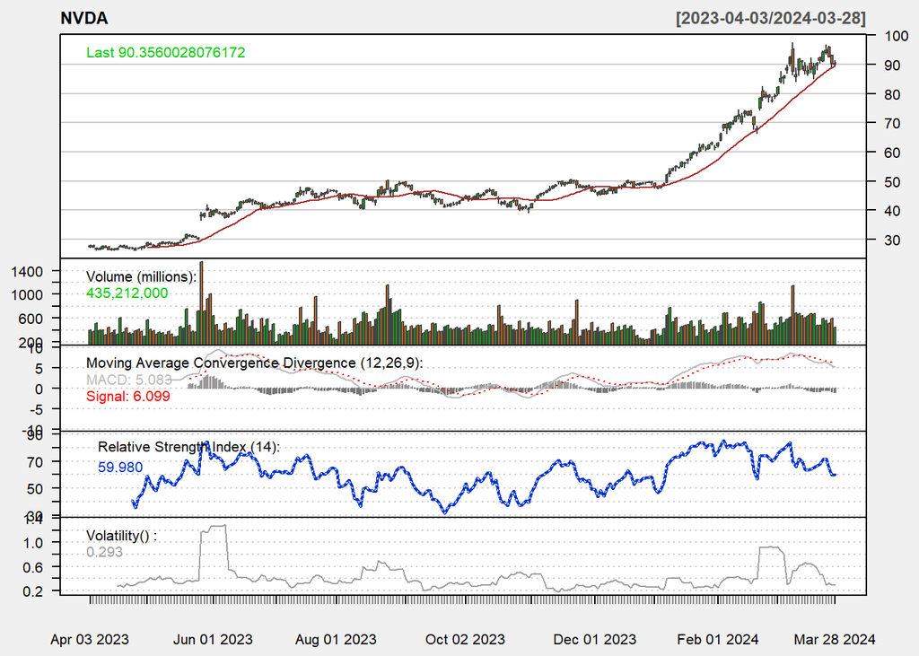

```r
chartSeries(NVDA, TA = "addVo();addMACD();addRSI();addSMA(20);addVolatility()",theme = chartTheme("white"))
```

## **Part 4 - Build a simple ARIMA model to forecast next month’s prices for NVIDIA and Evaluate the model’s accuracy and discuss its implications.**

### **Load necessary libraries**

```r
library(forecast)
```

### **Visualization without forecasting**

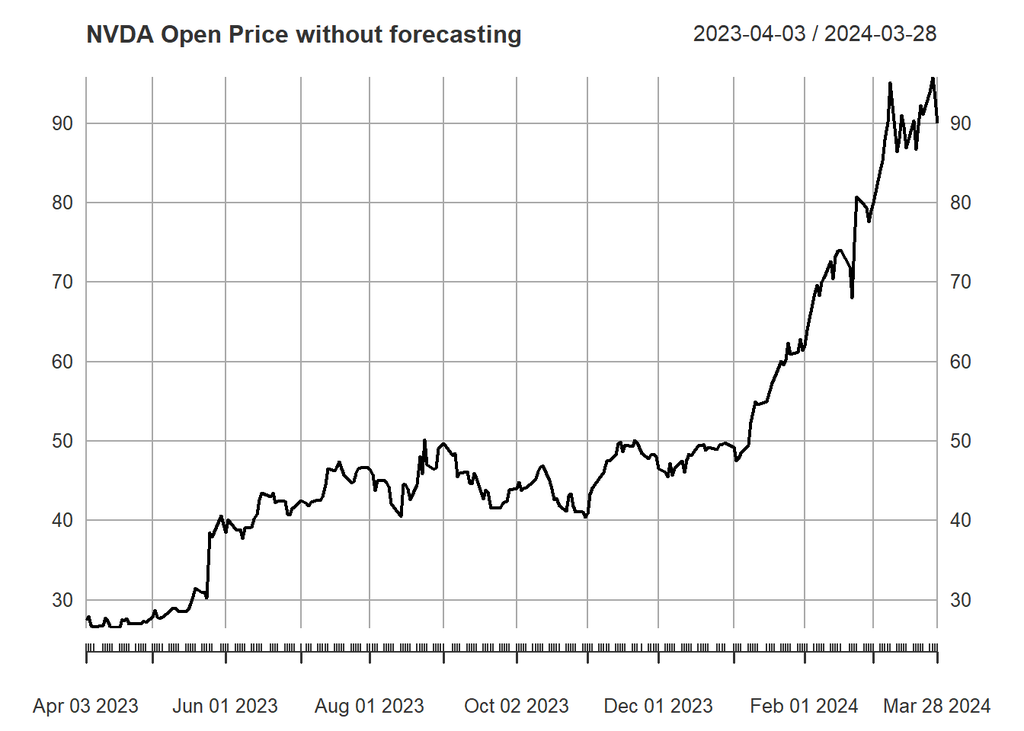

```r
plot(NVDA$NVDA.Open, main = "NVDA Open Price without forecasting")
```

### **Fit an ARIMA model**

```r
NVDA_OPfit <- auto.arima(NVDA$NVDA.Open)
```

### **Model parameters**

```r
summary(NVDA_OPfit)
```

```
## Series: NVDA$NVDA.Open
## ARIMA(0,1,1) with drift
##
## Coefficients:
##           ma1   drift
##       -0.1391  0.2541
## s.e.   0.0685  0.0908
##
## sigma^2 = 2.779:  log likelihood = -477.65
## AIC=961.3   AICc=961.4   BIC=971.84
##
## Training set error measures:
##                        ME     RMSE     MAE        MPE     MAPE      MASE
## Training set 9.373656e-05 1.657027 1.11468 -0.1575239 2.177063 0.9824078
##                     ACF1
## Training set 0.008703701
```

##### **ARIMA(0,1,1)**

##### **We have an ARIMA model: ARIMA(0,1,1)**

##### **0 for the AR (autoregressive) part, indicating no lagged term of the variable was used.**

##### **1 for the I (integrated) part, meaning the data has been differenced once to achieve stationarity.**

##### **1 for the MA (moving average) part, indicating that the model uses one lagged forecast error term.**

### **Check model diagnostics**

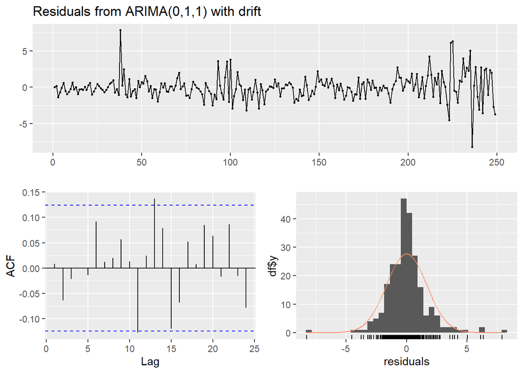

```
##
##  Ljung-Box test
##
## data:  Residuals from ARIMA(0,1,1) with drift
## Q* = 4.4063, df = 9, p-value = 0.8827
##
## Model df: 1.   Total lags used: 10
```

```r
checkresiduals(NVDA_OPfit)
```

### **Create a forecast**

```r
NVDA_OP_future_values <- forecast(NVDA_OPfit, 20)  # Forecasting next 20 values
```

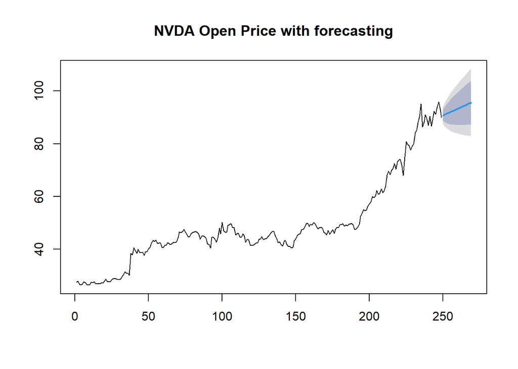

```r
plot(NVDA_OP_future_values, main = "NVDA Open Price with forecasting")
```